# Impacts of ambient temperature and clutch size on incubation behaviour onset in a female‐only incubator songbird - Diez‐Méndez - - Ibis - Wiley Online Library

Original Article

# Impacts of ambient temperature and clutch size on incubation behaviour onset in a female‐only incubator songbird

[David Diez‐Méndez](https://onlinelibrary.wiley.com/action/doSearch?ContribAuthorStored=Diez-M%C3%A9ndez%2C+David)

[Juan José Sanz](https://onlinelibrary.wiley.com/action/doSearch?ContribAuthorStored=Sanz%2C+Juan+Jos%C3%A9)

[Emilio Barba](https://onlinelibrary.wiley.com/action/doSearch?ContribAuthorStored=Barba%2C+Emilio)

First published: 01 March 2021

https://doi.org/10.1111/ibi.12937

Associate Editor: Catry Inês.

## Abstract

Ambient temperature is assumed to be the major cue used by passerines to synchronize their laying and hatching dates to the expected peak of prey availability. While laying eggs, females are still able to fine‐tune their hatching date following increasing or decreasing patterns of ambient temperature, mostly via changes in incubation onset. The onset of incubation behaviour in relation to the laying sequence could have later consequences for the duration of the incubation period and the extent of hatching asynchrony. Clutch size is also known to affect incubation patterns and might therefore condition potential responses to changing temperatures. In this study we assessed the association of ambient temperature and clutch size with the onset of four different incubation behaviours: partial and full nocturnal incubation, and partial and full diurnal incubation. We also evaluated how the onset and duration of each incubation behaviour might predict the duration of diurnal full incubation and the extent of hatching asynchrony. To achieve our aims, we monitored incubation behaviour using temperature data loggers during the egg‐laying period in three Mediterranean Great Tit *Parus major* populations in three consecutive years. Our results showed that increasing temperatures were related to an advance of diurnal partial incubation, but not its duration or the onset of full incubation behaviour. We did not find any effect of ambient temperatures on nocturnal incubation. However, females lengthened nocturnal partial incubation and delayed the onset of nocturnal full and diurnal partial incubation when laying larger clutches. Longer diurnal incubation before clutch completion was associated with greater hatching asynchrony. Moreover, longer diurnal partial incubation shortened the duration of the full incubation period. In conclusion, increasing ambient temperatures during the egg‐laying period advanced diurnal partial incubation, indirectly shortening the full incubation period and increasing hatching asynchrony.

Birds are able to track environmental cues to synchronize the peak of food demand by their nestlings with maximum prey abundance (Perrins 1991, Cresswell & McCleery 2003, Simmonds *et al*. 2017). For passerines that feed caterpillars to their nestlings, early spring temperature is a potential cue for future prey availability (Noordwijk *et al*. 1995, Visser *et al*. 1998, Matthysen *et al*. 2011) and females might use it to advance or delay their egg‐laying dates accordingly (Cresswell & McCleery 2003, Both & Visser 2005, Matthysen *et al*. 2011). Because ambient temperature still varies once egg‐laying has started, females may need to track these fluctuations to readjust egg‐hatching dates to the changing, expected caterpillar peak (Cresswell & McCleery 2003, Both & Visser 2005, García‐Navas & Sanz 2011, Matthysen *et al*. 2011).

Females advance hatching dates at increasing temperatures (Visser *et al*. 1998, Cresswell & McCleery 2003, Both & Visser 2005, Matthysen *et al*. 2011) or delay them during cold spells (Monrós *et al*. 1998, Naef‐Daenzer *et al*. 2004, García‐Navas & Sanz 2011, Kluen *et al*. 2011, Gądalski *et al*. 2018). The onset of incubation behaviour is the major determinant of reproductive timing once egg‐laying has started (Tomás 2015), and may open a temporal window of up to 16 days to readjust hatching dates within a population (García‐Navas & Sanz 2011, Simmonds *et al*. 2017).

Earlier incubation onset within the laying sequence shortens the incubation period (Nilsson & Svensson 1993a, Ardia & Clotfelter 2007) but increases hatching asynchrony (Nilsson & Svensson 1993a, Ardia *et al*. 2006, Johnson *et al*. 2013), which could end in brood reduction and unbalanced offspring growth (Slagsvold *et al*. 1995, Szöllosi *et al*. 2007, Stenning 2008). Conversely, delaying incubation onset beyond clutch completion may lengthen the incubation period and reduce hatching asynchrony. This may lead to heavier fledglings but has the drawback of reducing hatching success (Naef‐Daenzer *et al*. 2004, García‐Navas & Sanz 2011, Kluen *et al*. 2011).

The variability in the onset of incubation caused by ambient temperature may be narrowed by the effects of clutch size. Both laying eggs and incubation are energetically costly behaviours (Williams 2005, Nord & Williams 2015) and it may be difficult for females to incubate while laying eggs. For example, egg‐laying females are more able to advance incubation onset when energy constraints are alleviated via supplementary food during the egg‐laying period (Nilsson 1993), and may lay larger clutches when they are not constrained by an earlier prey peak so that there is no need to advance incubation behaviour into the egg‐laying period (Cresswell & McCleery 2003). Nevertheless, several studies have shown that either the onset of incubation is not affected by clutch size (Nilsson & Svensson 1993a, Ardia & Clotfelter 2007) or females may start incubation earlier relative to clutch completion (Aldredge *et al*. 2014, Álvarez & Barba 2014a), or earlier in the laying sequence (Wang & Beissinger 2009), when clutches are larger.

Incubation onset, as addressed in previous studies, can be equated to the onset of diurnal full incubation (Wang & Beissinger 2009, reviewed in Wang & Beissinger 2011), defined as the stable period of incubation during daylight hours (Haftorn 1981, Simmonds *et al*. 2017). However, some diurnal incubation may start earlier if females display what is known as partial incubation, a developing and irregular period of incubation (Haftorn 1981, Simmonds *et al*. 2017). To date, the consequences of diurnal partial incubation are contested. Whereas several studies highlight its importance in shortening the incubation period (Ricklefs 1993, Stoleson & Beissinger 1995, Wang & Beissinger 2011) and increasing hatching asynchrony (Veiga 1992, Lord *et al*. 2011, Johnson *et al*. 2013), others attribute such effects to the early onset of diurnal full incubation (Wang & Beissinger 2009, Podlas & Richner 2013). Moreover, nocturnal incubation is rarely considered (but see Wang & Beissinger 2009, Lord *et al*. 2011). Passerines incubate continuously during the night, in contrast to intermittent diurnal incubation (Deeming 2002), but females also go through a period of irregular partial incubation that lasts from a few minutes to several hours per night (Haftorn 1981, Pendlebury & Bryant 2005). Nocturnal, partial and full incubation behaviours might also have an effect on the duration of the incubation period, hatching asynchrony and hatching success (Wang & Beissinger 2009), but their exact role is unknown.

In this study we explored the early incubation behaviour of Great Tits *Parus major* in three different populations, focusing first on the onset and duration of the partial incubation behaviours, and then on the onset of nocturnal and diurnal full incubation. We assessed the association of ambient temperature with the different incubating periods and whether this was consistent among populations. We also investigated the size of the clutch as a correlate of onset of incubation in every population. We then explored the association of the different incubation behaviours with the duration of the incubation period (i.e. the duration of diurnal full incubation) and the extent of hatching asynchrony.

We expected that (i) increasing temperatures would be associated with an advance of the incubation behaviour into the egg‐laying period, and shorter partial incubation (i.e. speeding up the onset of full incubation behaviour); (ii) larger clutches would be associated with delayed onset of incubation behaviour; (iii) longer incubation behaviour during the egg‐laying period would be associated with increased hatching asynchrony; (iv) longer incubation before reaching diurnal full incubation would be associated with a shorter incubation period; and (v) increasing ambient temperatures would have similar associations with the onset of incubation behaviour across breeding populations.

## METHODS

### Study species

The Great Tit is a secondary hole‐nesting passerine species that easily accepts nestboxes. Females lay clutches of 4–13 eggs (Álvarez & Barba 2014b); the usual pattern is laying one egg per day, although they may skip a day, producing gaps in the laying sequence (Nilsson & Svensson 1993b, Monrós *et al*. 1998). The incubation period lasts 13 days on average (Álvarez & Barba 2014b) and females are the only incubator. Clutches hatch in 0–3 days (Álvarez & Barba 2014b). Females usually start nocturnal incubation shortly after laying the first egg, and diurnal incubation somewhat later in the laying sequence (see Haftorn 1981 for a detailed description). Full diurnal incubation behaviour is considered to start around the day the clutch is complete, although this behaviour is highly variable (Cresswell & McCleery 2003, Álvarez & Barba 2014b).

### Study areas

We collected data on first clutches during three breeding seasons (2015–2017) in three Spanish populations, where wooden nestboxes were available for the birds to breed in as part of long‐term studies on the species. The study area of Pina (40°1'12"N, 0°37'48"W, 1200 m asl) is a mixed forest composed of Portuguese Oaks *Quercus faginea* scattered within Maritime Pines *Pinus pinaster* woodlands. The population is located at Monte de Santa Bárbara de Pina in Eastern Spain and includes 200 nestboxes. Blue Tits *Cyanistes caeruleus* and Coal Tits *Periparus ater* also breed in the nestboxes (Alambiaga *et al*. 2020). The study area of Quintos (39°43'48"N, 3°58'48"W, 900 m asl) is part of the Quintos de Mora National Wildlife Reserve in Central Spain. Forest patches here are dominated by Pyrenean Oaks *Quercus pyrenaica* and, to a lesser extent, by Portuguese Oaks (e.g. Barrientos *et al*. 2015). Blue Tits, Eurasian Nuthatches *Sitta europaea* and Rock Sparrows *Petronia petronia* also breed in the 200 nestboxes available in the area. The study area of Sagunto (39°42'0''N, 0°15'0''W, 30 m asl) is within a homogeneous extensive orange *Citrus aurantium* plantation in Eastern Spain, where orange trees are uniformly distributed (e.g. Rodríguez *et al*. 2016). From approximately 500 available nestboxes, a sub‐area of 200 boxes was selected for the present study. Apart from the Great Tit, a few House Sparrows *Passer domesticus* and Tree Sparrows *Passer montanus* also occupy some nestboxes.

### General field methods

Nestboxes in each study area were inspected weekly from early spring, looking for signs of nest‐building. We increased the frequency of the visits during the nest‐building period up to daily after we found lining material. This allowed us to detect the first laid egg at each nest (i.e. laying date, 1 April = 1) in most cases (see below). Daily visits during the laying period allowed us to detect incubation behaviour (presence of uncovered and warm eggs, or direct observation of an incubating female). This was an approximation to the onset date of diurnal full incubation behaviour (which was determined more precisely later) and was useful for estimating hatching dates during fieldwork. Eleven days after the detection of incubation, we started visiting the nests twice a day to measure hatching asynchrony. We weighed the hatchlings at every visit (electronic balance; 0.1 g), until the last egg hatched or new hatchlings were absent for two consecutive visits. We used the weights from the visit at which the last egg was found to have hatched, and defined hatching asynchrony as the ratio of the lightest and heaviest hatchlings (following Ardia *et al*. 2006); thus lower ratios indicate higher asynchrony. Breeding parameters for each study area by year are provided in Table S1.

### Temperature data collection

We assessed incubation behaviour from recorded temperatures in the nest‐cup at each nest. When we detected eggs in a nest, the nest was carefully removed from the nestbox to place an inverted U‐shape mesh of galvanized steel covered by a cardboard platform. In the space between the mesh and the nestbox floor (15 mm height) we placed a HOBO UX100‐014M Single Channel Thermocouple data logger (Onset Computer Corporation, USA) fitted to collect data every 10 s. We connected a Type T 6 ft Beaded Thermocouple probe (30 wire gauge, accuracy ± 1.0 °C; Onset Computer Corporation) to the data logger and placed the nest back in the nestbox, over the cardboard (Fig. 1, Fig. S1). The raw probe was anchored to the centre of the clutch, being surrounded by the eggs. The raw probe was still highly mobile and females could bury or displace it from the centre of the nest‐cup, reducing the chances of collecting high‐quality data. To increase data collection efficiency, in 2017 the raw probe was implanted in a plastic craft egg (Factory Direct Craft Supply, USA) filled with wire‐pulling lubricant (Clear Glide, Ideal industries, USA), as used successfully in previous studies (Ardia *et al*. 2006, 2010, Cooper & Voss 2013). The plastic eggs (15.9 × 11.5 mm) resembled speckled Great Tit eggs, though slightly smaller (e.g. eggs in the Sagunto population averaged 18.1 × 13.3 mm; Encabo *et al*. 2001) (see Fig. S2).

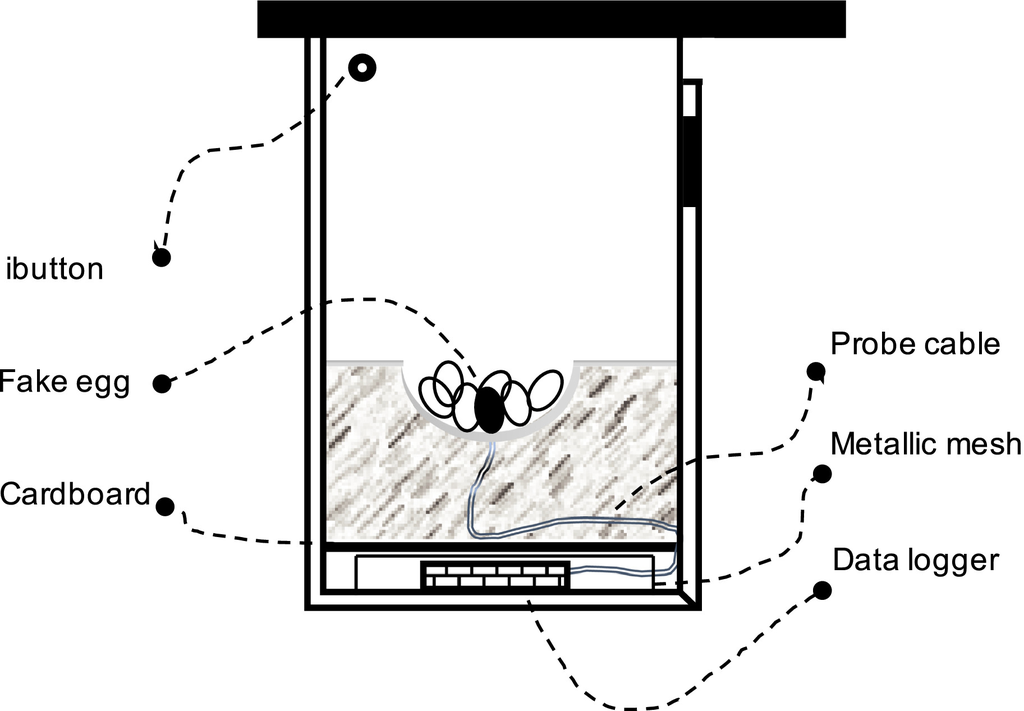

**Figure 1**

Diagram of a lateral view of a nestbox showing the experimental set‐up to measure both nest‐cup temperature and ambient temperature.

We set thermocouples in 29, 62 and 95 nests in Pina, Quintos and Sagunto, respectively. Three nests in Pina (10.3%) and six in Quintos (9.7%) failed before incubation started due to female desertion, and an additional nest was preyed upon in Pina. In Sagunto, 21 nests failed before clutch completion (22.1%) due to female desertion (16) and outsider human manipulation (5). From the 25 deserted nests among the three populations, breeding females stopped laying eggs after datalogger placement in 11 (6% of nests with dataloggers). From the resulting successful nests, we discarded those with low‐quality temperature data caused by the displacement of the probe from the centre of the clutch or by it being buried during the recording period, after a preliminary visual inspection of temperature patterns (see Fig. S3 for a comparison). In total, we had 77 nests available for fine‐scale incubation analyses (16, 22 and 39 nests in Pina, Quintos and Sagunto, respectively). From these nests, six were not used in analyses of duration of the incubation period because females deserted a few days before hatching (i.e. incubation day 11 onwards), and four additional nests were not used in analyses of hatching asynchrony because we could not weigh hatchlings on focal days. For the 77 nests, we set thermocouples on the day of the first egg day in 52 nests (67.5%). In the remaining 25, thermocouples were set during the second egg‐laying day in 11 nests, the third day in eight nests, the fourth in five nests and the fifth in one nest.

To measure ambient temperature at the nest, we placed Thermochron iButton data loggers (accuracy ± 0.5 °C, Model DS1922L‐F5, Maxim Integrated, USA) in the upper part of one of the inner walls of the nestbox, fixed with brown adhesive tape, recording local ambient temperature every 520 s. When an iButton was lost (i.e. a member of the breeding pair detached it from the inner wall), we used temperature data from the closest nestbox, choosing the dates of interest. During 2015, temperature in Quintos was only provided by two empty nestboxes installed for that purpose in the study area. Ambient temperature for each study area by year and incubation behaviour is provided in Table S2.

### Incubation behaviour

We used the software combination of Rhythm and Raven (Cooper & Mills 2005) to analyse recorded temperatures in the nest‐cup and to discriminate between on‐bouts (i.e. periods of time that a female is incubating the clutch in the nest) and off‐bouts (i.e. periods of time that a female is foraging or carrying out self‐maintenance activities out of the nest). Our criteria to delimit off‐bouts in Rhythm were a minimum decrease in egg temperature of 2.0 °C, a minimum initial cooling slope of 0.2 °C/min and a minimum off‐bout duration of 2 min. The output of Rhythm was visually inspected in Raven to verify the timing and duration of incubation off‐ and on‐bouts.

The cut‐off point between diurnal partial and full incubation was set as the first day that incubation behaviour lasted at least 50% of the active day; that is, the first day a female incubated at least half of the time between the first off‐bout in the early morning and the last on‐bout in the evening (following Cresswell & McCleery 2003, Simmonds *et al*. 2017). For nocturnal incubation, the cut‐off point was considered when females incubated steadily over the whole night (100% of the inactive day) for the first time (Haftorn 1981) (Fig. 2). The incubation period, or more accurately the full incubation period, was defined as the elapsed days from onset of full incubation to the day preceding hatching date, measured in days.

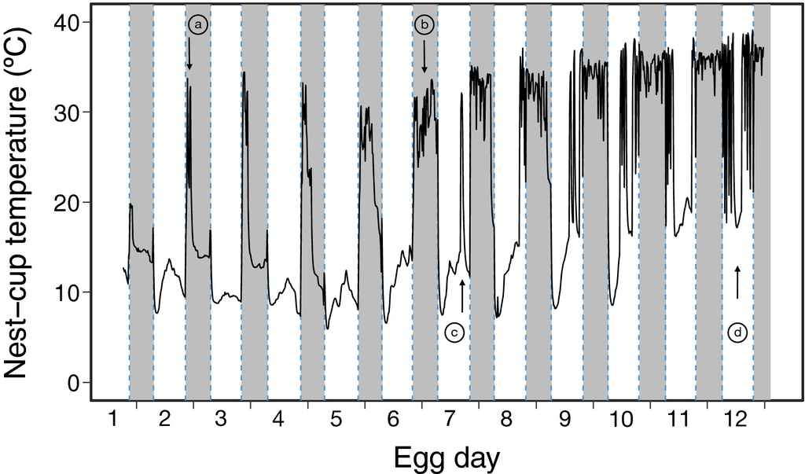

**Figure 2**

Raw data showing the variation in nest‐cup temperature from the laying date (egg day 1) until the onset of diurnal full incubation. (a) Onset of nocturnal partial incubation, (b) onset of nocturnal full incubation, (c) onset of diurnal partial incubation and (d) onset of diurnal full incubation. Shadowed areas highlight nocturnal inactive daytime hours.

We reported the onset of incubating periods as both the number of elapsed days since the first egg was laid (laying date = egg day 1) and the number of days since clutch completion (clutch completion day = 0), following recommendations in Wang and Beissinger (2011). However, we only used the former for statistical analyses, as this variable better allowed us to account for when the females start to incubate in the laying sequence, and to account for the effect of clutch size by adding the latter variable into the models. The duration of nocturnal and diurnal partial incubation was reported as the total sum of minutes and the number of days of partial incubation (Table 1). For statistical models we only used partial incubation duration in minutes as a more accurate variable.

Table 1. Descriptive statistics of the nocturnal and diurnal partial incubation behaviour.

|  | *n* | Pina mean ± sd | Range | *n* | Quintos mean ± sd | Range | *n* | Sagunto mean ± sd | Range |  |
| --- | --- | --- | --- | --- | --- | --- | --- | --- | --- | --- |
| Nocturnal partial incubation |  |  |  |  |  |  |  |  |  |  |
| Duration (approximate) |  |  |  |  |  |  |  |  |  |  |
| Number of days | 16 | 5.2 ± 2.51 | 1–10 | 22 | 5.4 ± 1.59 | 3–9 | 38 | 4.7 ± 1.80 | 0–8 |  |
| Sum of minutes | 16 | 1364 ± 681 | 374–3084 | 22 | 1258 ± 369 | 758–2140 | 38 | 1077 ± 506 | 0–2006 |  |
| Nocturnal full incubation |  |  |  |  |  |  |  |  |  |  |
| Onset |  |  |  |  |  |  |  |  |  |  |
| Egg day | 16 | 7.0 ± 2.03 | 4–11 | 22 | 7.7 ± 1.55 | 5–10 | 38 | 7.0 ± 1.46 | 3–10 |  |
| Clutch completion | 16 | 0.8 ± 1.75 | −2 to 5 | 22 | −0.8 ± 1.85 | −3 to 1 | 38 | −0.8 ± 1.09 | −6 to 1 |  |
| Diurnal partial incubation |  |  |  |  |  |  |  |  |  |  |
| Onset |  |  |  |  |  |  |  |  |  |  |
| Egg day | 15 | 7.7 ± 2.19 | 5–12 | 20 | 7.7 ± 1.78 | 4–11 | 38 | 6.7 ± 1.40 | 4–9 |  |
| Clutch completion | 15 | 0.5 ± 1.92 | −2 to 5 | 20 | −1.8 ± 1.51 | −4 to 2 | 38 | −2.1 ± 1.25 | −5 to 0 |  |
| Duration |  |  |  |  |  |  |  |  |  |  |
| Number of days | 15 | 3.5 ± 1.13 | 2–5 | 21 | 2.1 ± 1.00 | 0–4 | 39 | 2.3 ± 1.08 | 0–5 |  |
| Sum of minutes | 14 | 696 ± 214 | 207–1035 | 21 | 331 ± 215 | 0–933 | 39 | 366 ± 182 | 0–710 |  |
| Diurnal full incubation |  |  |  |  |  |  |  |  |  |  |
| Onset |  |  |  |  |  |  |  |  |  |  |
| Egg day | 16 | 11.4 ± 2.50 | 7–16 | 22 | 9.9 ± 1.58 | 7–12 | 39 | 9.0 ± 1.06 | 7–11 |  |
| Clutch completion | 16 | 4.2 ± 2.54 | 0–9 | 22 | 0.4 ± 1.37 | −2 to 4 | 39 | 0.3 ± 0.86 | −1 to 2 |  |

- Egg day refers to the number of days since the first egg was laid at each nest (laying date = egg day 1) and clutch completion refers to the number of days since the clutch was completed (clutch completion day = 0). *n* denotes the number of nests.

### Statistical analyses

We conducted statistical analyses using R software 3.6.1 (R Core Team 2019). We built several linear models (LMs) to assess the association between mean ambient temperature and the onset and duration of diurnal partial incubation, the duration of nocturnal partial incubation, and the onset of both diurnal and nocturnal full incubation (see Fig. 3 for further model details). Laying date and clutch size were added to models as covariates and study population and year as categorical effects. For the model for onset of diurnal partial incubation, we also added mean ambient temperature (from laying date to the day prior to the onset of diurnal partial incubation) as a covariate. For the models for duration of nocturnal and diurnal partial incubation, we added mean ambient temperature during the partial incubation period and the egg day on which partial incubation began as covariates. For the models for onset of full diurnal and nocturnal incubation, we added the mean temperature value for the preceding partial incubation period, and the egg day each partial incubation started as covariates. We only provided descriptive statistics for the onset of nocturnal partial incubation because most of the females started to incubate the day they laid the first egg and we lack temperature data before the laying date to model any association between ambient temperature and the onset of this behaviour. In the case of nests where the datalogger was set after egg day 1, we considered the onset of nocturnal partial incubation to happen on the egg day when data collection started, as the better approximation for data analysis, although we are aware that this could have resulted in underestimation of nocturnal partial incubation periods. To test our hypothesis about the effect of ambient temperature across populations, we built two candidate models for each dependent variable, one of them including the interaction between the breeding population and ambient temperature and the other one without such an interaction. We selected the most informative model based on Akaike's information criterion (AIC) following Burnham and Anderson (2002) via the *MuMIn* package (Bartón 2015). If both models were equally informative (ΔAICc < 2.0), we selected the most parsimonious one, with no interactions (see Table S3 for model selection results).

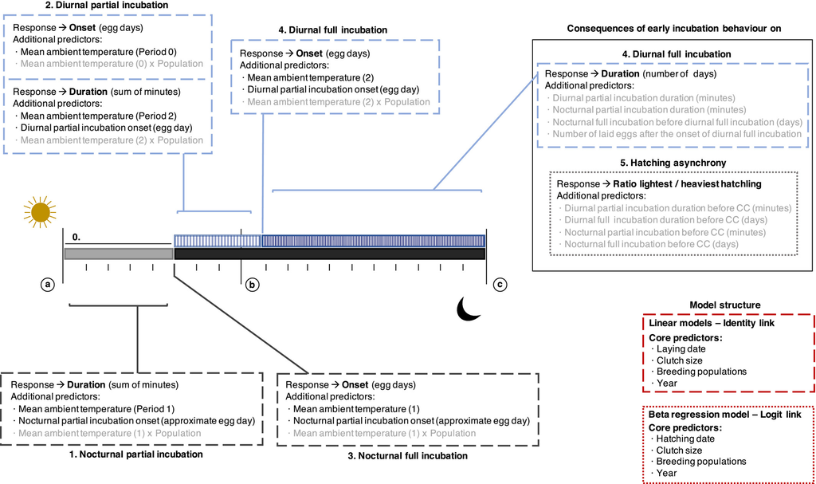

**Figure 3**

Schematic representation of the different incubation behaviour periods displayed by an incubating female and the variables used in the statistical models. Variables in grey were subject to model selection. (a) Refers to laying date, (b) to clutch completion day (CC) and (c) to hatching date. Horizontal striped bars show diurnal partial (2) and full (4) incubation and filled bars represent nocturnal partial (1) and full (3) incubation.

Following the same rationale, to explore the consequences of the different incubating behaviours for the duration of the full incubation period and the extent of hatching asynchrony, we built a set of LMs and of beta regression models, respectively. Beta regression models allowed us to use ratios from hatching asynchrony data as a dependent variable by applying a logit link (*betareg* package, Cribari‐Neto & Zeileis 2010). We added laying date, clutch size, population and year as predictors in LMs for the duration of the full incubation period and hatching date, clutch size, population and year as predictors in beta regression models for hatching asynchrony. Both LMs and beta regression models contained different combinations of the incubation behaviours potentially displayed by females until the onset of the full incubation period (i.e. diurnal partial incubation and nocturnal partial and full incubation) or until clutch completion, respectively (i.e. diurnal partial and full incubation and nocturnal partial and full incubation). We compared candidate models and selected the most informative one based on AIC values (Table S4).

We analysed final selected models, reported their *R*<sup>2</sup> values and considered as significant *P*‐values < 0.05. Numerical predictors were centred, and residuals of the response variable were visually inspected to check normality and homogeneity of the variance. Because final LMs showed residual data points with high leverage values or outliers, we reran the models applying an iterated re‐weighted least squares methodology that weighs down the effect of outliers and recalculates estimates and standard errors, reducing the influence of these data points on the model estimates (*Robustbase* package, Maechler *et al.,* 2015). We report means ± sd unless otherwise stated.

## RESULTS

### Nocturnal incubation

Nocturnal partial incubation was a ubiquitous behaviour in our breeding populations, lasting 1203 ± 522 min (for population‐level summaries see Table 1). Females breeding in Pina and Quintos displayed partial incubation from the evening when egg‐laying commenced in all of the 16 nests where the thermocouple was set from the first day. The other 22 females breeding in these two populations were engaged in nocturnal partial incubation when data collection started, except one female from Quintos that started on egg day 5. In contrast, only 15 of 36 females from Sagunto (in nests where we collected data since egg day 1) started nocturnal partial incubation that first evening. Except for one female that immediately displayed nocturnal full incubation, females breeding in Sagunto started nocturnal partial behaviour 1.91 ± 0.98 days after laying the first egg (range = 1–4, *n* = 35).

We did not find any effect of ambient temperature on the duration of partial nocturnal incubation (estimate ± se = −7.1 ± 80.60, *t* = −0.088, *P* = 0.930), but the larger the clutch, the longer nocturnal partial incubation lasted (estimate ± se = 164.6. ± 65.99, *t* = 2.494, *P* = 0.015; Table 2, Fig. 4a). Our model also showed that the duration of nocturnal partial incubation was similar in the three studied populations (Table 2), although we had reduced power to detect such differences because we did not collect complete nocturnal partial incubation data in 23 of 77 nests.

Table 2. Results of the linear models analysing the effects of laying date, clutch size, breeding population, mean ambient temperature and year on the nocturnal partial incubation duration (sum of minutes) and the onset of nocturnal full incubation (days since the laying date)

|  | Estimate | se | *t* | *P* |
| --- | --- | --- | --- | --- |
| Nocturnal partial incubation duration |  |  |  |  |
| *R*<sup>2</sup> = 0.17 |  |  |  |  |
| Intercept | 1197.0 | 255.33 | 4.688 |  |
| Laying date | −28.3 | 100.15 | −0.283 | 0.778 |
| Clutch size | **164.6** | **65.99** | **2.494** | **0.015** |
| Quintos | −274.5 | 236.06 | −1.163 | 0.249 |
| Sagunto | −326.1 | 320.28 | −1.018 | 0.312 |
| Mean temperature | −7.1 | 80.60 | −0.088 | 0.930 |
| Year 2016 | **308.4** | **127.76** | **2.414** | **0.019** |
| Year 2017 | **328.9** | **139.39** | **2.360** | **0.021** |
| Nocturnal partial incubation onset | −63.8 | 53.48 | −1.193 | 0.237 |
| Nocturnal full incubation onset |  |  |  |  |
| *R*<sup>2</sup> = 0.54 |  |  |  |  |
| Intercept | 6.97 | 0.582 | 11.968 |  |
| Laying date | −0.11 | 0.230 | −0.497 | 0.621 |
| Clutch size | **1.01** | **0.154** | **6.520** | **< 0.001** |
| Quintos | −0.61 | 0.539 | −1.132 | 0.262 |
| Sagunto | −0.64 | 0.733 | −0.878 | 0.383 |
| Mean temperature | −0.11 | 0.186 | −0.611 | 0.543 |
| Year 2016 | **1.04** | **0.296** | **3.505** | **0.001** |
| Year 2017 | **0.65** | **0.321** | **2.039** | **0.045** |
| Nocturnal partial incubation onset | **0.41** | **0.122** | **3.330** | **0.001** |

- The categorical variables year and population were assessed in comparison with the reference year 2015 and the reference population Pina. Significant effects are highlighted in bold.

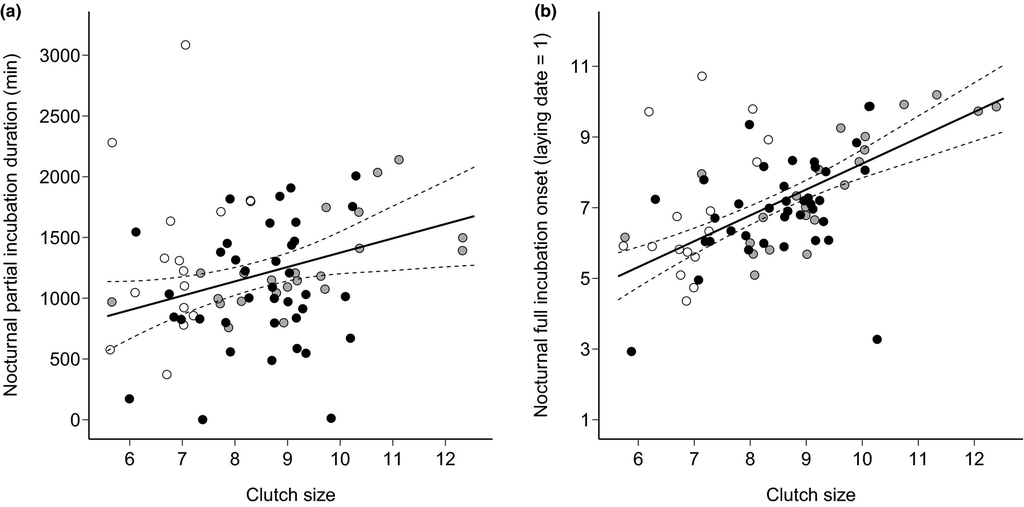

**Figure 4**

Variation of (a) the duration of partial incubation (sum of minutes) and (b) the onset of nocturnal full incubation in relation to clutch size. Dashed lines denote 95% confidence intervals obtained with the package *effects* (Fox 2003). Circles represent raw data from the three populations: empty circles show nests from Pina, grey circles from Quintos and black circles from Sagunto.

The onset of nocturnal full incubation was not related to ambient temperatures (estimate ± se = −0.11 ± 0.186, *t* = −0.611, *P* = 0.543), but the larger the clutch, the later it started (estimate ± se = 1.01 ± 0.154, *t* = 6.520, *P* < 0.001; Table 2, Fig. 4b). Females showed great variability in nocturnal full incubation onset relative to the laying sequence, from egg day 3 to 11, or as early as 6 days before clutch completion and up to 5 days after it (Table 1). We discarded one nest from Sagunto where nocturnal full incubation was not achieved during the recording of incubation behaviour (see Fig. S4). The starting day of nocturnal full incubation was similar at the three breeding populations (Table 2) but differed among years (reference year 2015; 2016 estimate ± se = 1.04 ± 0.296, *t* = 3.505, *P* = 0.001; 2017 estimate ± se = 0.65 ± 0.321, *t* = 2.039, *P* = 0.045).

### Diurnal incubation

Diurnal partial incubation was also displayed by almost all females, except one in Quintos and one in Sagunto, which immediately started diurnal full incubation (i.e. ≥ 50% of the active day incubating). The earliest a female started diurnal partial incubation was after laying the fourth egg, or 5 days before clutch completion. Females displayed 427 ± 259 min of diurnal partial incubation (for population‐level summaries see Table 1). We discarded one nest from Pina and another from Quintos because females partially incubated for twice as long as the maximum recorded (10 and 8 days compared with 5 and 4 days, respectively) and showed erratic behaviour, not progressing as expected or even interrupting partial incubation (0% of nest attentiveness at some point during the period) (see Figs S5 and S6). Diurnal partial incubation always started after partial nocturnal incubation behaviour had already begun (Figs S4–S6).

Females displayed diurnal partial incubation earlier in the laying sequence when temperatures were higher (estimate ± se = −0.8 ± 0.25, *t* = −3.233, *P* = 0.002; Table 3, Fig. 5a). However, onset was delayed for larger clutches delayed (estimate ± se = 0.8 ± 0.20, *t* = 3.671, *P* < 0.001; Table 3, Fig. 5b). Diurnal partial incubation onset differed among years (reference year 2015; 2016 estimate ± se = 1.0 ± 0.39, *t* = 2.577, *P* = 0.012; 2017 estimate ± se = −0.1 ± 0.40, *t* = −0.356, *P* = 0.723) but we did not find differences among breeding populations (Table 3). Females allocated fewer minutes to diurnal partial incubation when it started later in the laying sequence (estimate ± se = −69.4 ± 29.96, *t* = −2.317, *P* = 0.024) but we did not find a clear effect of ambient temperature on the duration of diurnal partial incubation (estimate ± se = −13.6 ± 33.84, *t* = −0.402, *P* = 0.689; Table 3). When comparing populations, females from Pina showed a longer diurnal partial incubation period compared with those from the other sites (Quintos estimate ± se = −421.3 ± 103.06, *t* = −4.088, *P* < 0.001; Sagunto estimate ± se = −450.1 ± 127.30, *t* = −3.536, *P* = 0.001; Table 3).

Table 3. Results of the linear models analysing the effects of laying date, clutch size, mean ambient temperature, breeding population and year on the onset (days since the laying date) and duration (in minutes) of diurnal partial incubation and the onset of diurnal full incubation (days since the laying date)

|  | Estimate | se | *t* | *P* |
| --- | --- | --- | --- | --- |
| Diurnal partial incubation onset |  |  |  |  |
| *R*<sup>2</sup> = 0.40 |  |  |  |  |
| Intercept | 6.9 | 0.81 | 8.597 |  |
| Laying date | 0.2 | 0.32 | 0.512 | 0.610 |
| Clutch size | **0.8** | **0.20** | **3.671** | **< 0.001** |
| Quintos | −0.3 | 0.77 | −0.361 | 0.719 |
| Sagunto | 0.1 | 1.00 | 0.090 | 0.929 |
| Mean temperature | −**0.8** | **0.25** | −**3.233** | **0.002** |
| Year 2016 | **1.0** | **0.39** | **2.577** | **0.012** |
| Year 2017 | −0.1 | 0.40 | −0.356 | 0.723 |
| Diurnal partial incubation duration |  |  |  |  |
| *R*<sup>2</sup> = 0.38 |  |  |  |  |
| Intercept | 796.6 | 106.96 | 7.447 |  |
| Laying date | −60.1 | 43.78 | −1.373 | 0.175 |
| Clutch size | −27.1 | 32.22 | −0.842 | 0.403 |
| Quintos | −**421.3** | **103.06** | −**4.088** | **< 0.001** |
| Sagunto | −**450.1** | **127.30** | −**3.536** | **0.001** |
| Mean temperature | −13.6 | 33.84 | −0.402 | 0.689 |
| Year 2016 | −12.7 | 59.71 | −0.213 | 0.832 |
| Year 2017 | −21.2 | 59.73 | −0.355 | 0.724 |
| Diurnal partial incubation onset | −**69.4** | **29.96** | −**2.317** | **0.024** |
| Diurnal full incubation onset |  |  |  |  |
| *R*<sup>2</sup> = 0.67 |  |  |  |  |
| Intercept | 11.1 | 0.51 | 21.701 |  |
| Laying date | −0.4 | 0.21 | −1.666 | 0.101 |
| Clutch size | 0.1 | 0.16 | 0.465 | 0.644 |
| Quintos | −**1.9** | **0.50** | −**3.785** | **<0.001** |
| Sagunto | −**2.0** | **0.61** | −**3.327** | **0.001** |
| Mean temperature | −0.2 | 0.16 | −1.446 | 0.153 |
| Year 2016 | 0.3 | 0.29 | 1.070 | 0.288 |
| Year 2017 | 0.3 | 0.29 | 1.062 | 0.292 |
| Diurnal partial incubation onset | **1.06** | **0.145** | **7.328** | **< 0.001** |

- The categorical variables year and population were assessed in comparison with the reference year 2015 and the reference population Pina. Significant effects are highlighted in bold.

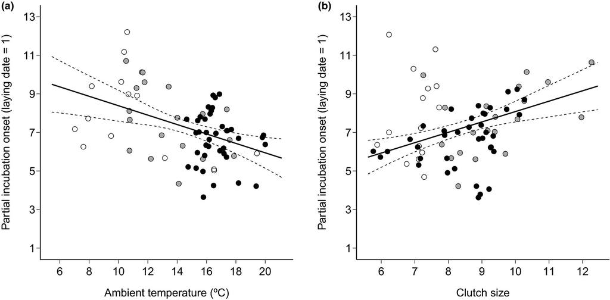

**Figure 5**

Variation of the onset of partial incubation in relation to (a) mean ambient temperature since the laying date and (b) clutch size. Dashed lines denote 95% confidence intervals obtained with the package *effects*. Circles represent raw data from the three populations: empty circles show nests from Pina, grey circles from Quintos and the black circles from Sagunto.

Females started to display full incubation behaviour as early as 2 days before clutch completion, and as late as 9 days after. Relative to the laying sequence, no female started diurnal full incubation before the seventh egg day (Table 1). The night before diurnal full incubation started, all females, except one in Sagunto, were already displaying nocturnal full incubation. The later a female began partially to incubate the clutch during the day, the later diurnal full incubation started (estimate ± se = 1.06 ± 0.145, *t* = 7.328, *P* < 0.001; Table 3). We did not find a clear association of ambient temperature with the onset of diurnal full incubation in any breeding population (estimate ± se = −0.2 ± 0.16, *t* = −1.446, *P* = 0.153) (Table 3). Full incubation onset was similar among years but differed among populations: females from Pina started later in the laying sequence than females elsewhere (Quintos estimate ± se = −1.9 ± 0.50, *t* = −3.785, *P* < 0.001; Sagunto estimate ± se = −2.0 ± 0.61, *t* = −3.327, *P* = 0.001; Table 3).

### Effects of early incubation behaviour

Table 4. Results of the linear and beta regression models analysing the effects of laying date, clutch size, breeding population, year and diurnal partial incubation on the duration of diurnal full incubation period and the extent of hatching asynchrony (ratio between the smallest and the heaviest hatchling) respectively

[output not shown]

- The hatching asynchrony model was built using hatching date instead of laying date, and the addition of diurnal partial and full incubation duration before clutch completion. The categorical variables year and population were assessed in comparison with the reference year 2015 and the reference population Pina. Significant effects are highlighted in bold.
- <sup>a</sup> For the hatching asynchrony model we provided *z‐*values.

## DISCUSSION

Ambient temperature during the egg‐laying period was associated only with advance of the onset of diurnal partial incubation, and the effect was similar in the three breeding populations. We did not find any independent association of ambient temperature with the onset of diurnal full incubation, but the diurnal partial incubation advance pulled it forward. Clutch size showed an important association with early incubation behaviour: larger clutches were associated with delayed onset of diurnal partial incubation, lengthened nocturnal partial incubation and delayed onset of nocturnal full incubation. Only the diurnal stages of incubation were directly associated with duration of the full incubation period and the extent of hatching asynchrony. However, both ambient temperature and clutch size, through their associations with the duration of diurnal partial incubation in opposite directions, indirectly predicted full incubation duration and hatching asynchrony.

### Nocturnal incubation behaviour

Nocturnal incubation has been proposed to be a protective response for embryos against low temperatures (Haftorn 1978); warmer conditions would delay its onset (Wang & Beissinger 2009). However, incubating female songbirds do not display nocturnal incubation during the egg‐laying period when ambient temperatures are close to freezing (Zerban & Morton 1983, Morton & Pereyra 1985, Clotfelter & Yasukawa 1999), or at least not regularly (Johnson *et al*. 2013). Moreover, if nocturnal partial incubation is displayed, it does not last until the lowest temperatures occurring close to sunrise (this study, see also Haftorn 1981, Pendlebury & Bryant 2005, Lord *et al*. 2011). An alternative explanation for the early onset of nocturnal incubation may be protection against warm nights to preserve egg hatchability (Lord *et al*. 2011, see also the egg viability hypothesis; Veiga 1992, Stoleson & Beissinger 1999). However, our data also disagree with the latter hypothesis, as females from the warmest population (Sagunto) started nocturnal incubation on average 2 days later than the others. We lack suitable data to propose a strong alternative hypothesis, although body size, hormone levels and prey availability may play important roles in the early stages of incubation (see below). Moreover, pre‐laying abiotic factors such as ambient temperature (Simmonds *et al*. 2017) or photoperiod (Lambrechts *et al*. 1997) that affect laying date may also impact the onset of nocturnal partial incubation.

Clutch size is unlikely to affect the onset of nocturnal partial incubation but was the only variable that was associated with nocturnal behaviour (see also Haftorn 1981, Vedder 2012). That only smaller clutches were associated with advanced onset of nocturnal full incubation (but see Wang & Beissinger 2009) might suggest that breeding females cannot cope with both laying eggs and full nocturnal incubation, or at least not early in the laying sequence. In this scenario, it might be expected that females with better body condition could increase nocturnal nest attentiveness faster and reach nocturnal full incubation earlier, although a previous study found that better body condition correlated with longer partial nocturnal incubation periods in precocial Wood Ducks *Aix sponsa* (Grimaudo *et al*. 2020).

### Diurnal incubation behaviour

Incubation behaviour (equated with our definition of full incubation) starts earlier in the laying sequence at increasing ambient temperatures (Naef‐Daenzer *et al*. 2004, Kluen *et al*. 2011) or earlier relative to clutch completion (Ardia *et al*. 2006, García‐Navas & Sanz 2011, but see Wang & Beissinger 2009). Our results showed that increasing temperatures after the laying date were associated with an advance of the onset of diurnal partial incubation, but not of diurnal full incubation. As the main driver for advancing the onset of full incubation was an earlier onset of partial incubation, an apparent advance of diurnal full incubation might still be expected even when partial incubation is not measured. However, we cannot discount the possibility that temperatures themselves could directly advance the onset of diurnal full incubation in other populations or species.

None of the breeding females displayed diurnal incubation before the fourth egg day, or nocturnal full incubation before the third egg day. We have mentioned that the onset of nocturnal full incubation was delayed in larger clutches, and we observed the same in the diurnal partial incubation onset. The association with clutch size may be explained to some extent by the close relationship between both diurnal and nocturnal behaviours. Exploratory analysis showed that the onset of both behaviours is positively correlated (*r* = 0.64, *P* < 0.001); that is, females initiated nocturnal full incubation on average the same evening after they began to display diurnal partial incubation (0.1 ± 1.67 days, range = −5 to 7, *n* = 71). Although larger clutch sizes delayed both diurnal partial and nocturnal full incubation behaviour, we did not find a delaying effect of clutch size on the onset of diurnal full incubation. This lack of effect is in line with most previous studies (Nilsson & Svensson 1993a, Matthysen *et al*. 2011), including those where the onset of incubation was measured relative to the clutch completion date, which did not find an effect of clutch size on the onset of incubation (Ardia *et al*. 2006, García‐Navas & Sanz 2011).

The fact that only two of 77 females skipped diurnal partial incubation strongly suggests that it may be a necessary precursor to full, stable incubation behaviour. As for nocturnal partial incubation, female body condition may be a key determinant of diurnal partial incubation. For example, experimental approaches have shown that females provided with extra food during the laying period started to incubate earlier (Nilsson 1993, Nilsson & Svensson 1993a, Eikenaar *et al*. 2003, Gilby *et al*. 2013). Physiological factors may contribute as well to limit incubation behaviour: hormones such as prolactin increase gradually during egg‐laying (reviewed in Vleck 2002, Marasco & Spencer 2015) and the brood patch develops throughout the laying period (e.g. Haftorn 1981, Massaro *et al*. 2006, Barrionuevo & Frere 2016). Our results also showed that the later in the laying sequence the diurnal partial incubation started, the shorter it was, suggesting that females are able to speed up incubation behaviour later in the laying sequence.

### Consequences of early incubation behaviour

Diurnal incubation behaviour during the egg‐laying period is known to shorten the (full) incubation period (Stenning 1996, Ardia *et al*. 2006, García‐Navas & Sanz 2011, Vedder 2012, Aldredge 2017, Diez‐Méndez *et al.,* 2020, but see Podlas & Richner 2013). There is also some evidence that nocturnal behaviour might contribute to shortening that period (Lord *et al*. 2011). Our results showed that, among the considered incubation stages, shortening the full incubation period could be only attributed to a longer diurnal partial incubation. Starting full incubation earlier than clutch completion was not associated with the duration of full incubation. We have previously discussed that females advanced diurnal partial incubation at increasing temperatures, and the earlier into the laying sequence they started, the longer it lasted. In this scenario, females would indirectly shorten the full incubation period at increasing temperatures, which contributes to advanced hatching dates and hatching success (Nord & Nilsson 2012, Macdonald *et al*. 2013, Diez‐Méndez *et al.,* 2020) but also entails higher hatching asynchrony (see below).

Although we did not detect a direct association of clutch size with full incubation duration, larger clutches would indirectly cause the opposite effect from increasing ambient temperature: lengthening the full incubation period by delaying, and then shortening, diurnal partial incubation. The role of clutch size on the duration of diurnal full incubation period is still controversial. In line with our findings, females may have difficulties incubating larger clutches, resulting in eggs reaching lower temperatures during full incubation, and thus lengthening the period of incubation (Nord & Nilsson 2012). By contrast, larger clutches show higher thermal inertia, cooling down more slowly when females leave the nest (Boulton & Cassey 2012) and facilitating higher intensity of incubation and shortening the full incubation period (Cooper *et al*. 2005). Positive and negative effects of clutch size may cancel out each other, resulting in the lack of effect found in this study.

Incubation behaviour before the clutch is fully laid causes hatching asynchrony (Nilsson & Svensson 1993a, Ardia *et al*. 2006, Johnson *et al*. 2013, but see Wang & Beissinger 2009, Podlas & Richner 2013). We found that this effect was mainly due to females displaying diurnal partial incubation before completing the clutch. Diurnal full incubation before clutch completion also contributed to hatching asynchrony, but females displayed this behaviour in only 11 of 77 nests. We did not find any association between nocturnal incubation behaviour and hatching asynchrony, even though nocturnal partial incubation lasted two to three times longer than diurnal partial incubation and mostly started immediately after the first egg was laid. Both partial and full nocturnal incubation could exceed physiological zero temperature (26–28 °C, Drent 1975) and reach incubation temperatures (36–38 °C, Haftorn 1978, 1979, 1981, Lord *et al*. 2011, Vedder 2012, Podlas & Richner 2013, Simmonds *et al*. 2017; but see Pendlebury & Bryant 2005), potentially affecting embryo development. However, we did not detect any clear effect of these nocturnal periods on hatching asynchrony.

Breeding females only reacted to increasing temperatures by advancing diurnal partial incubation into the laying period, which indirectly increased the degree of hatching asynchrony (see also Naef‐Daenzer *et al*. 2004, Ardia *et al*. 2010, Johnson *et al*. 2013). Larger clutches, however, seemed to deter earlier onsets of incubation. In a scenario of uneven warmer springs, breeding females may follow different strategies in different populations. Assessing how phenological changes in clutch size, incubation behaviour and hatching spreads occur in each population may help to understand avian responses to climate change.

We would like to thank all the collaborators and students for their assistance during the breeding seasons 2015–2017 in Sagunto and Pina, and specially José Verdejo for his help in Pina. We also thank Inês Catry and two anonymous reviewers for their valuable comments that substantially improved the paper. This study was supported by projects CGL2013‐48001‐C2‐1‐P and CGL2016‐79568‐C3‐1‐P (Spanish Ministry of Economy and Competitiveness, MINECO). D.D.‐M. benefitted from an FPI fellowship (BES‐2014‐069191) provided by the MINECO. D.D.‐M. conducted the analyses and wrote the manuscript. All authors contributed to the study design, data collection and editing of the manuscript.

## AUTHOR CONTRIBUTIONS

**David Diez‐Méndez:** Conceptualization (equal); formal analysis (lead); methodology (equal); visualization (lead); writing–original draft (lead). **Juan Jose Sanz:** Conceptualization (equal); funding acquisition (equal); methodology (equal); project administration (equal); supervision (supporting); writing–review and editing (supporting). **Emilio Barba:** Conceptualization (equal); funding acquisition (equal); methodology (equal); project administration (equal); supervision (lead); writing–review and editing (lead).

### Details

- © 2021 British Ornithologists' Union

### Research funding

  - Ministerio de Economía y Competitividad. Grant Numbers: BES‐2014‐069191, CGL2013‐48001‐C2‐1‐P, CGL2016‐79568‐C3‐1‐P

### Keywords

  - [Great Tit](https://onlinelibrary.wiley.com/action/doSearch?field1=Keyword&text1=Great%20Tit)
  - [hatching asynchrony](https://onlinelibrary.wiley.com/action/doSearch?field1=Keyword&text1=hatching%20asynchrony)
  - [nest attentiveness](https://onlinelibrary.wiley.com/action/doSearch?field1=Keyword&text1=nest%20attentiveness)
  - [nocturnal incubation](https://onlinelibrary.wiley.com/action/doSearch?field1=Keyword&text1=nocturnal%20incubation)
  - [partial incubation](https://onlinelibrary.wiley.com/action/doSearch?field1=Keyword&text1=partial%20incubation)
  - [*Parus major*](https://onlinelibrary.wiley.com/action/doSearch?field1=Keyword&text1=%0AParus%20major%0A)

### Publication History

  - Version of Record online: 01 March 2021
  - Manuscript accepted: 28 January 2021
  - Manuscript revised: 29 December 2020
  - Manuscript received: 26 July 2020